# Entrega final R para Ciência de Dados II

Alessandra Ribeiro

14/09/2020

## Populismo e Ideologia no Brasil (1999 - 2019)

### Introdução

O presente relatório trata-se de uma atividade avaliativa para conclusão do curso “R para Ciência de Dados II” oferecido pelos professores Caio Lente e William Amorim. O objetivo deste relatório é apresentar uma análise de ciência de dados utilizando da linguagem R. Dessa forma, escolhi analisar a relação entre populismo e ideologia no executivo federal brasileiro. O banco de dados escolhido foi o “*Global Populism Database*”, desenvolvido pelos pesquisadores Hawkins, Kirk A., Rosario Aguilar, Erin Jenne, Bojana Kocijan, Cristóbal Rovira Kaltwasser e Bruno Castanho Silva.

O banco tem como objetivo mensurar o quanto os presidentes e primeiros ministros de países ao redor do mundo são populistas. Nesta análise estão representados 40 países com observações no período de 2000 a 2019. Como forma de operacionalizar o conceito de populismo, os pesquisadores analisaram discursos públicos dos dirigentes nacionais destacando uma retórica que mobiliza “a vontade das pessoas comuns em conflito com elites conspiradoras” (Hawkins, K. et al., 2019, p. 2). Esses critérios estão alinhados à definição de Mudde (2004, apud Taggart, 2018, p. 80), amplamente aceita no campo de estudos sobre populismo. Segundo o autor, o populismo é uma ideologia que considera que a sociedade é separada em dois grupos homogêneos e antagônicos: “o povo puro” contra “a elite corrupta”, no qual se argumenta que a política deve ser uma expressão da vontade geral do povo (Mudde, 2004 apud Taggart, 2018, p. 80).

Dessa forma, com base nos critérios acima descritos, os pesquisadores atribuíram pesos aos discursos para a construção de um índice que varia entre 0,0 – 0,4 (Not Populist), 0,5 – 0,9 (Somewhat Populist), 1,0 – 1,3 (Populist), 1,5 – 1,9 (Very Populist). Além disso, a base também contém strings sobre países, regiões (Europe and Central Asia, Latin America and Caribbean, North America e South Asia), nome do líder e partido. Entre as variáveis numéricas, estão: um índice de espectro político, indo de -1 a 1 (correspondendo à esquerda e direita, respectivamente). Uma outra variável dicotômica informa se o líder político é presidente ou primeiro ministro, sendo atribuído 1 e 0 respectivamente.

O objetivo desta análise é relacionar o grau de populismo à ideologia política dos presidentes do Brasil entre 1999 e 2019. A análise abarca cinco diferentes representantes: Fernando Henrique Cardoso, Lula (no banco, os mandatos de Lula aparecem como uma única variável), Dilma (diferentemente, os mandatos de Dilma foram separados), Michel Temer e Jair Bolsonaro.

Por ideologia, entendo a posição de um representante em um espectro político que varia em esquerda, centro e direita. A operacionalização desse conceito não é consenso nos estudos políticos e, infelizmente, não tive acesso à construção do índice no banco utilizado. Avalio que para futuras análises é imprescindível acessar conhecer a forma a qual este índice foi calculado.

Por fim, analisar a relação entre populismo e ideologia é particularmente interessante quando comparamos Lula e Bolsonaro, dois representantes frequentemente avaliados como populistas e que posicionam-se em pólos opostos do espectro político.

### Resultados

Em um primeiro momento, carrego os pacotes que serão utilizados na análise.

```r
library(dplyr)
library(ggplot2)
library(readxl)
library(janitor)
```

A base de dados *Global Populism Database* estava disponível em planilha Excel. Abaixo realizo a importação da base, filtrando apenas observações de presidentes brasileiros.

```r
caminho <- "data-raw/Populist speech data.xlsx"

pop_br <- read_excel(caminho) %>%
  filter(country == "Brazil") %>%
  clean_names()
```

O primeiro resultado é uma série histórica que indica a variação do grau de populismo no Brasil desde FHC até Bolsonaro. O eixo x apresenta a mudança dos mandatos por ano, nomeadas pelos respectivos presidentes. O eixo y contém o índice de populismo. O gráfico mostra que Lula, Dilma no segundo mandato e Bolsorano apresentaram algum grau de populismo. FHC, Temer e Dilma no primeiro mandato não aparecem no gráfico porque identificou-se um grau 0 de populismo. No entanto, para a categorização do *Global Populism Database*, apenas Bolsonaro pode ser considerado em alguma medida populista (somewhat populist).

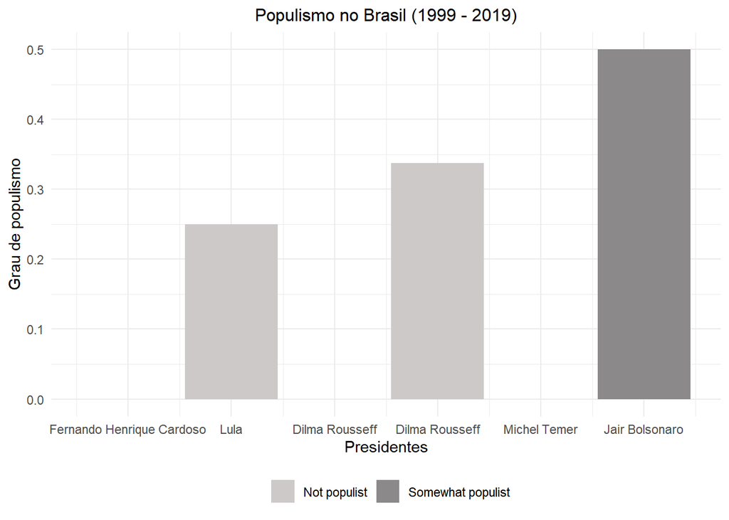

```r
ggplot(data = pop_br, aes(
  x = code_year,
  y = average_score,
  fill = speech_category)) +
  geom_col() +
  labs(x = "Presidentes",
       y = "Grau de populismo",
       title = "Populismo no Brasil (1999 - 2019)",
       fill = "") +
    scale_fill_manual(values = c("snow3", "snow4")) +
    scale_x_continuous(breaks = pop_br$code_year,
                       labels = pop_br$leader) +
  theme_minimal() +
  theme(
    legend.position = "bottom", plot.title = element_text(hjust = 0.5, size = 12))
```

É possível observar que nos últimos anos de governo (2015 e 2016), Dilma foi mais populista que Lula. Podemos levantar a hipótese de que diante do momento de fragilidade colocado pelo impeachment, Dilma intensificou o apelo às suas bases evocando a retórica populista, diferentemente dos anos iniciais, em que a ex-presidenta teve maior governabilidade. Outro aspecto que destaco é que Lula, embora apresente falas populistas, não foi classificado como um representante populista. O dado que o banco apresenta a esse respeito vai contra a afirmação que equipara Lula e Bolsonaro em termos de populismo (apenas um exemplo: https://istoe.com.br/populismo-economico-de-bolsonaro-e-igual-ao-de-lula/).

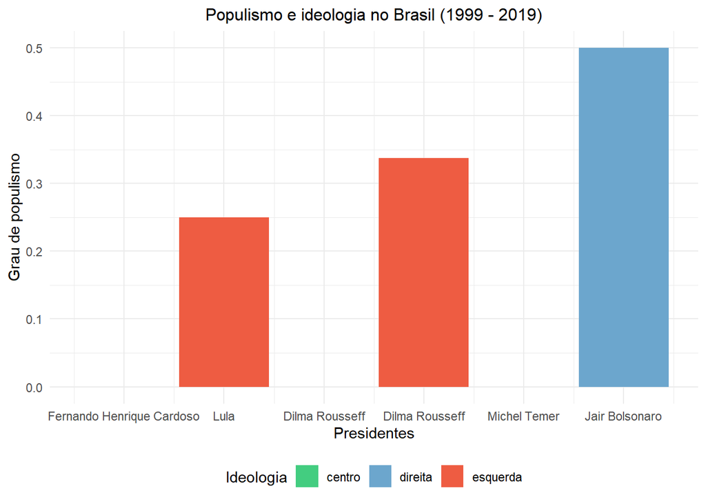

```r
ggplot(data = pop_br, aes(
    x = code_year,
    y = average_score,
    fill = ideol_category)) +
    geom_col() +
    labs(x = "Presidentes",
         y = "Grau de populismo",
         title = "Populismo e ideologia no Brasil (1999 - 2019)",
         fill = "Ideologia") +
    scale_fill_manual(values = c("seagreen3", "skyblue3", "tomato2")) +
    scale_x_continuous(breaks = pop_br$code_year,
                       labels = pop_br$leader) +
    theme_minimal() +
    theme(legend.position = "bottom",
          plot.title = element_text(hjust = 0.5, size = 12))
```

No gráfico acima envidencio a variável ideologia. O índice a respeito do espectro político classifica FHC e Michel Temer como centro, Lula e Dilma como esquerda e Bolsonaro como direita. Essa observação levanta a questão do populismo de esquerda x populismo de direita. Se coloca como um obstáculo à interpretação do populismo a associação automática a partidos de extrema direita ou líderes carismáticos (Vittori, 2017). Embora Lula não tenha sido categorizado como populista, líderes de esquerda como Evo Moralez e Hugo Chávez apresentam-se como populistas de acordo com o banco.

### Conclusão

Com base no que foi discorrido, não é possível com os dados levantados explicar a relação entre populismo e ideologia. Para os limites do presente trabaho, um exercício mais oportuno consiste no levantamento de problemas e hipóteses para futuras análises.

### Bibliografia

Hawkins, K. A., Aguilar, R., Castanho Silva, B., Jenne, E. K., Kocijan, B., and Rovira Kaltwasser, C. 2019. “Measuring Populist Discourse: The Global Populism Database”. Paper presented at the 2019 EPSA Annual Conference in Belfast, UK, June 20-22.

Taggart, Paul. (2018). Populism and ‘unpolitics’. In G. Fitzi, J. Mackert, & B. S. Turner (Eds.), *Populism and the crisis of democracy. Volume 1: Concepts and theory* (pp. 79–87). New York, NY: Routledge.

Vittori, Davide. Reconceituando o populismo: construindo um conceito multifacetado mais estrito. Estudos Eleitorais no Mundo, 2017, Volume 12 – nº 3.

https://populism.byu.edu/Pages/Data

https://noticias.uol.com.br/politica/ultimas-noticias/2019/04/04/jair-bolsonaro-populista-fernando-collor-pesquisa-bruno-castanho.htm